# Getting Started with R Markdown

K. D. Erickson

5/20/2021

# 1 What is R Markdown?

R Markdown allows you to combine your R code, figures, analysis, and long-form notes all in one place. Some people even write their entire manuscripts in RMarkdown!

There is so much you can do with R Markdown, today we will just scratch the surface.

Here is an example of a Markdown output:

- [Example HTML page](https://kerickson22.github.io/share/exploring_vital_rates_M.html)
- [Example presentation](https://kerickson22.github.io/share/Presentation_example.html)
- [a long figure](https://kerickson22.github.io/share/simulating_collector_bias.html)

# 2 Why R Markdown?

Keep notes about what and *why* you are doing something right along with your code

Useful for:

- Keeping a coding notebook
- Sharing with collaborators (especially those who don’t use R!)
- Publish reports/summaries
- Share code snippets/results on your website
- Teaching
- Visualizing large plots
- Keeping track of figures

# 3 Orientation to a R Markdown file

## 3.1 The header

An R Markdown file (*.Rmd) starts with a YAML header that sets certain document properties:

[figure not shown]

`output:` controls what type of document your markdown file will render to:

- html_document
- html_notebook
- pdf_document
- word_document

Because Markdown was originally developed for html, there are the most options available for html documents.

RStudio includes a bunch of commonly used options to select from in the Output Options… menu:

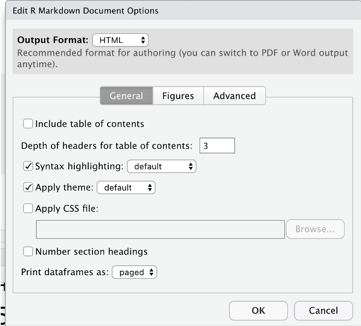

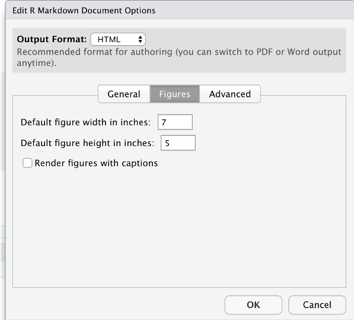

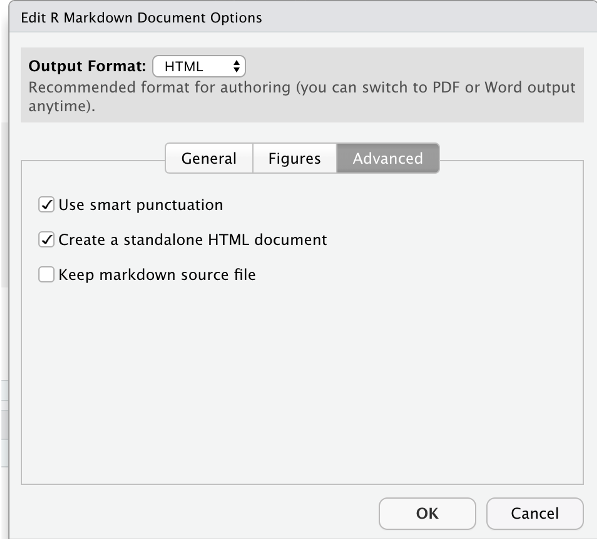

Selecting choices and clicking ok will update the YAML header for you.

## 3.2 Code Chunks

Anatomy of a code chunk:

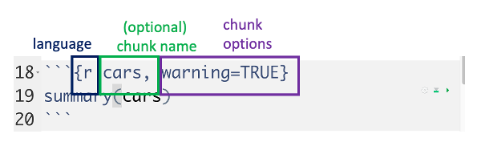

At the top right of each chunk there are some controls:

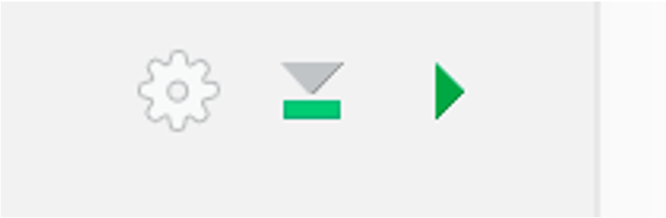

Click the gear to adjust chunk options, the down-ward arrow with the line underneath to run all chunks above the current chunk, and the right arrow to runk just this chunk.

# 4 Setup

The first chunk in an R Markdown document is special and controls some global chunk options.

Since the option `include=FALSE` is included in the chunk options, it will not be displayed in the output file.

I like to load packages in this chunk, as well as load data files.

One thing to note about RMarkdown is that it handles setting the working directory differently than you may be used to.

By default, the working directory is the directory that contains the markdown file.

If you use `setwd()` to set the working directory, it will only apply to the current chunk (and you will get a warning message about this)

If you want to change the working directory for the entire document, you can use `knitr::opts_knit$set(root.dir = '/tmp')` to change the root directory for the entire document.

You can read more about setting the working directory [here](https://bookdown.org/yihui/rmarkdown-cookbook/working-directory.html)

## 4.1 Including Plots

You can include a plot like so:

Setting the chunk option `echo=FALSE` will hide the R code from that chunk in the rendered document.

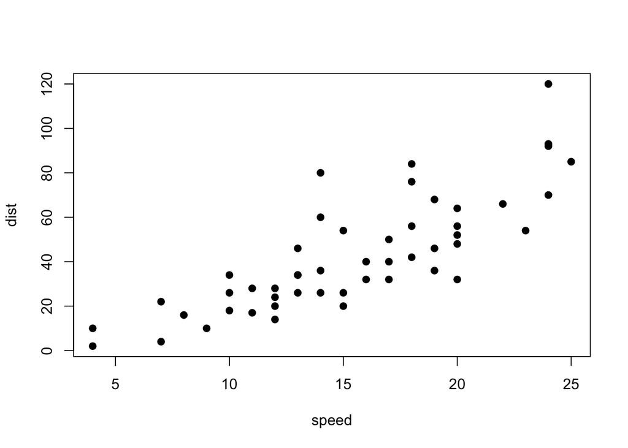

## 4.2 Including multiple plots on the same line

To control how many plots are shown in one row, use `fig.show="hold"` and `out.width="XX%$`, where XX is 50% if you want two per line, 33% for three, 25% for 4, etc.

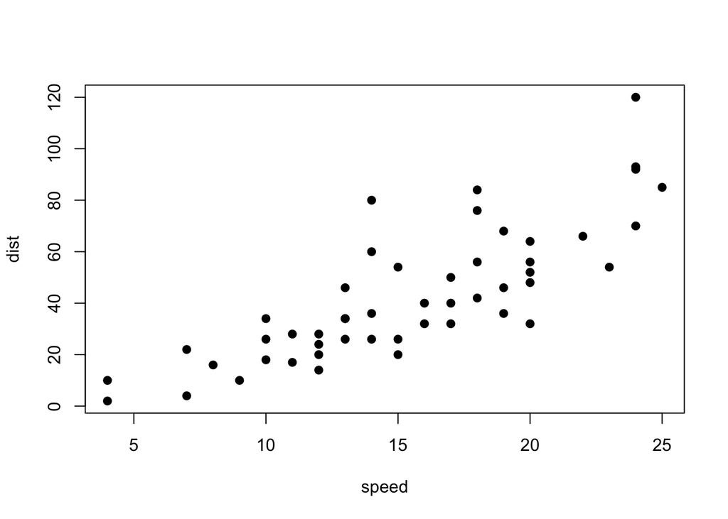

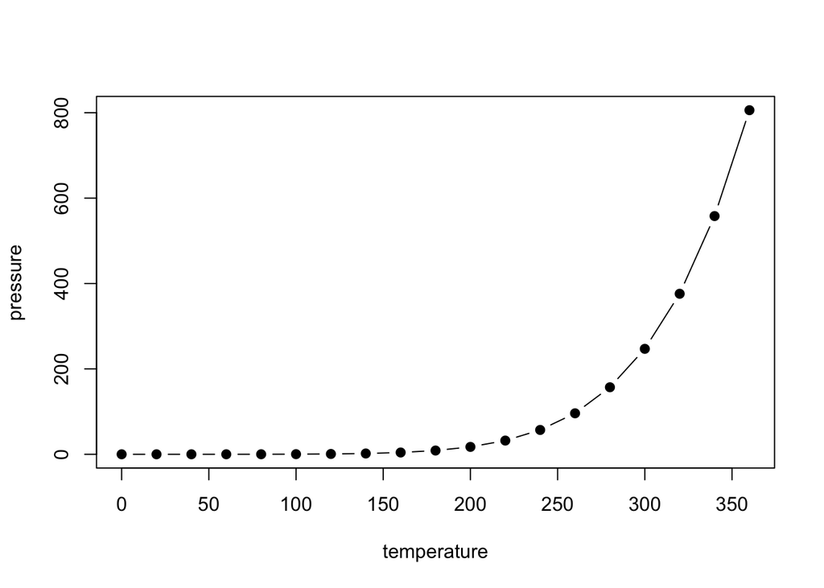

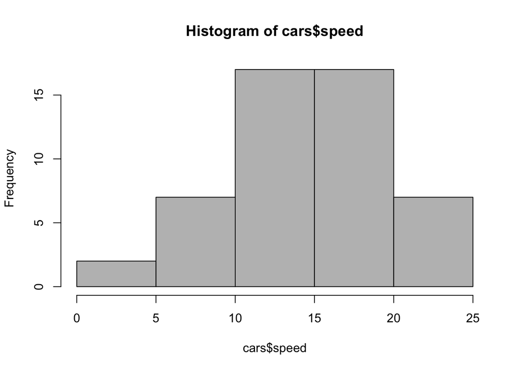

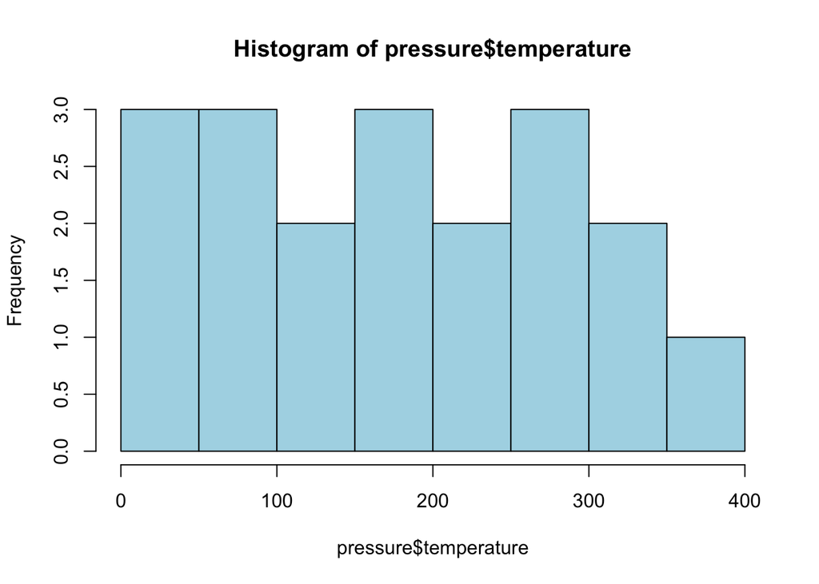

```r
plot(cars, pch=19)
plot(pressure, pch=19, type='b')
hist(cars$speed, col="grey")
hist(pressure$temperature, col="lightblue")
```

You can also use par, although that doesn’t always work with `ggplots`

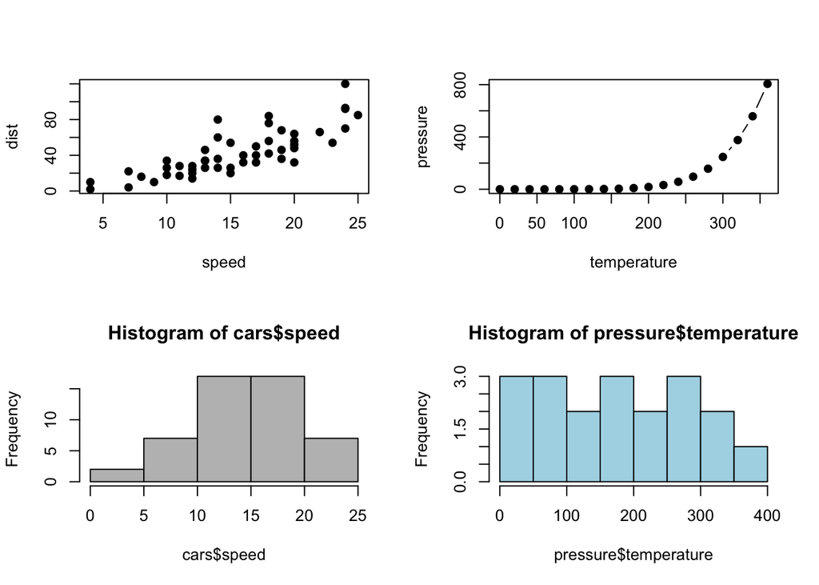

```r
par(mfrow=c(2,2))
plot(cars, pch=19)
plot(pressure, pch=19, type='b')
hist(cars$speed, col="grey")
hist(pressure$temperature, col="lightblue")
```

## 4.3 Including tables

```r
kable(head(pressure), digits=2)
```

| temperature | pressure |
| --- | --- |
| 0 | 0.00 |
| 20 | 0.00 |
| 40 | 0.01 |
| 60 | 0.03 |
| 80 | 0.09 |
| 100 | 0.27 |

```r
#digits: controls how many digits to display in the table
```

## 4.4 Writing out equations

You can make use of $\LaTeX$ to write out mathematical equations, either inline like so: $y = \beta_0 + \beta_1 x_1 + \beta_2 x_{1}^2$

or on a separate line in display mode:

$$\int_{-\infty}^{\infty} \mu_x dx$$

See https://detexify.kirelabs.org/classify.html for a helpful link for looking up $\LaTeX$ symbols, either by drawing them or looking through a chart. And see https://www.overleaf.com/learn/latex/Learn_LaTeX_in_30_minutes for a brief intro to the power of $\LaTeX$

# 5 When to cache

For analyses that take a while to run, you can use `cache=TRUE` in the chunk options.

The first time you render the document, that chunk will run and generate output that will be stored in a cache folder. As long as you don’t make changes to that code chunk, you can keep on updating other chunks and the next time you **Knit** your document, it will make use of the stored cache instead of running that chunk again.

Make sure that you don’t need to use any of the variables you define in the chunk outside of the script.

I have found that certain analyses that take a long time to run (hours or days) end up running much slower in R Markdown, so sometimes I instead use the option `eval=FALSE` to prevent that chunk from running, run just that chunk in the console, save the output to an RData file, and load that data file into the next chunk to make use of that output. (you can also do this in a chunk but beware it might take a while)

# 7 Some helpful links:

- [The book on R Markdown](https://bookdown.org/yihui/rmarkdown/)
- [R Markdown Cheatsheet](https://github.com/rstudio/cheatsheets/raw/master/rmarkdown-2.0.pdf)
- [A blog on using R Markdown to create reproducible research](https://elifesciences.org/labs/cad57bcf/composing-reproducible-manuscripts-using-r-markdown)
- [A gallery of examples](https://rpubs.com)
- [Teaching resources](https://datacarpentry.org/lessons/#ecology-workshop)